# PACTA for Banks Demo

Trang Tran

Resources: i. [PACTA for Banks Methodology](https://pacta.rmi.org/wp-content/uploads/2024/05/PACTA-for-Banks-Methodology-document_v1.2.3_030524.pdf)  
ii. [PACTA for Banks Packages](https://rmi-pacta.github.io/pacta.loanbook/index.html)  
iii. [Step-by-step Instruction](https://rmi-pacta.github.io/pacta.loanbook/articles/cookbook_overview.html)  
iv. [PACTA Scenario Support Document](https://pacta.rmi.org/wp-content/uploads/2022/10/20221010-PACTA-for-Banks_Scenario-Supporting-document_v1.3.1_final.pdf)  
v. [PACTA for Banks Knowledge Hub](https://rmi.gitbook.io/pacta-knowledge-hub/introduction/pacta)

## **1. Overview**

- **Purpose**: Measure the alignment of banks’ financial portfolios to various climate scenarios across a set of key climate-relevant sectors based on granular, physical asset-level data.
- **Scope**:
- **Sectors**: 7 sectors, only cover the most emission-tensive segment in the value chain

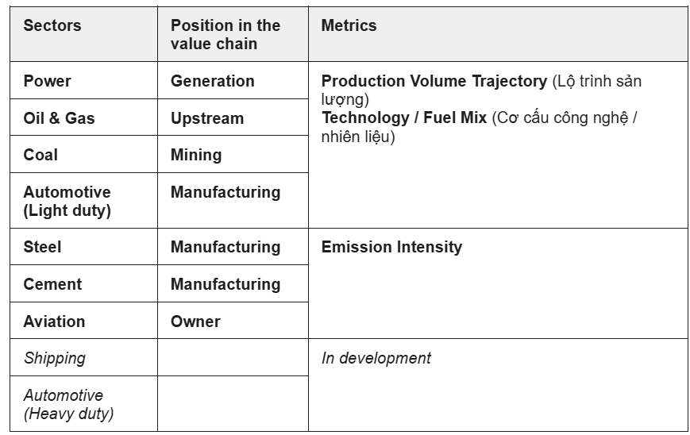

- **Financial assets**: Only cover **loans** (other assets like equity or bonds are covered in Pacta for Investors tool). Can either use the **drawn amount** (outstanding loans) or the **committed amount** (both undrawn & drawn loans) for the analysis.
- **Time horizon**: 5 years forward
- **Package**:

| Package | Short Description | Function |
| --- | --- | --- |
| **r2dii.data** | Dataset Templates | Provides mock datasets and templates for loan books and asset-level data. |
| **r2dii.match** | Data Linking | Uses fuzzy-matching algorithms to link bank clients to physical assets. |
| **r2dii.analysis** | Core Calculation | Calculates Technology Mix, Production Trajectories, and Emission Intensity. |
| **r2dii.plot** | Visualization | Generates standardized charts to visualize alignment with climate scenarios. |

## **2. Methodology**

Step 1: Gather inputs: loanbook, asset-based company data, climate scenarios.  
Step 2: Map loans from the bank’s loanbook to physical assets in the real economy and their corresponding production values.  
Step 3: Measure & visualize portfolio alignment & company alignment in 3 metrics and 2 approaches, depending on the sector.

- **Accounting principles**:
  - Portfolio alignment (Portfolio-weighted approach): Allocates economic assets (production volume/capacity & emission responsibility) based on the weight of the financial asset in the portfolio. This is to measure the overall contribution of the bank to real-economy emissions and to compare with peers & market.
  - Company alignment (Unweighted approach): Allocate absolute production values of a company to the portfolio level (meaning the portfolio accounts for the whole emission from that each of the clients). This is to identify the leading emitters in the portfolio.
- **3 metrics & 2 approaches to measure alignment**:
  - **Technoloy/Fuel Mix** applied to **sectors with clear low-carbon technology pathway** (Power, Oil & Gas, Coal, & Automotive), alignment compared by **Market Share Approach**: the share of different technologies or fuels (e.g., coal, gas, renewables) within a specific sector. PACTA aligns the current and projected (5-year) technology mix of a portfolio or client with the target mix prescribed by climate scenarios for that market. The effort to achieve alignment is distributed based on the company’s actual market share.
  - **Production Volume Trajectory** applied to **sectors with clear low-carbon technology pathway** (Power, Oil & Gas, Coal, & Automotive) alignment compared by **Market Share Approach**: the projected production volumes in 5 years from the base year. PACTA measures the alignment of a portfolio or client’s projected production volumes against the absolute trends prescribed in climate scenarios. It tracks the expansion of low-carbon technologies and the contraction of high-carbon ones over a 5-year horizon. The effort to achieve alignment is distributed based on the company’s actual market share.
  - **Emission Intensity** applied to **sectors without low-carbon technology pathway** (Cement, Steel, & Aviation), alignment compared by **Sectoral Decarbonization Approach (convergence approach)**: the average CO2 emitted per product unit. PACTA compares the average CO2 intensity of a portfolio or client against a reference intensity prescribed by climate scenarios. It requires the portfolio or client to meet the same sector-wide intensity target by the scenario’s end date, regardless of their starting point.

[figure not shown]

## **3. Demo with mock dataset from r2dii.data**

**Important note for the demo:**  
- Assume the data is already clean and requires no further validation. In a real-world scenario, data cleaning steps would be mandatory.  
- Only consider **portfolio-weighted approach** as it would be most relevant to our scope of work.  
- To view full analysis procedure, please refer to the **Step-by-step Instruction** pinned at the top of this document.

### 3.1. Prepare the tool

Need to install: R Studio, R language & the following packages

```r
library("rmarkdown")
library("pacta.loanbook")
library("r2dii.data")
library("r2dii.analysis")
library("r2dii.match")
library("r2dii.plot")
library("dplyr")
library("ggplot2")
library("scales")
library("tidyr")
```

### **3.2. Prepare the input**

PACTA is data-agnostic. None of the inputs below are available by PACTA itself and should be prepared by users. All the data points have **data dictionary** which we can refer to in input preparation.

#### **3.2.1. Loan book**

- Source: Prepared by Bank
- Required input:
  - `id_loan`: <character>
  - `id_direct_loantaker`: <character>
  - `name_direct_loantaker`: <character>
  - `id_ultimate_parent`: <character>
  - `name_ultimate_parent`: <character>
  - `loan_size_outstanding`: <numeric>
  - `loan_size_outstanding_currency`: <character>
  - `loan_size_credit_limit`: <numeric>
  - `loan_size_credit_limit_currency`: <character>
  - `sector_classification_system`: <character>
  - `sector_classification_direct_loantaker`: <character>
  - `lei_direct_loantaker`: <character>
  - `isin_direct_loantaker`: <character>
- For sector classfication: We have previously done VSIC & NAICS mapping, so if we proceed this analysis for Vietnamese banks, we can ultilize that.
- Below is the demo:

```r
ap_loanbook <- r2dii.data::loanbook_demo %>%
  mutate(sector_classification_direct_loantaker = as.character(sector_classification_direct_loantaker)) %>%
  left_join(sector_classifications, by = c(
    "sector_classification_system" = "code_system",
    "sector_classification_direct_loantaker" = "code"
  )) %>%
  rename(
    sector_matched = sector,
    borderline_matched = borderline
  )

paged_table(ap_loanbook)
```

| id_loan | id_direct_loantaker | name_direct_loantaker | id_ultimate_parent | name_ultimate_parent | loan_size_outstanding | loan_size_outstanding_currency | loan_size_credit_limit | loan_size_credit_limit_currency | sector_classification_system | sector_classification_direct_loantaker | lei_direct_loantaker | isin_direct_loantaker | sector_matched | borderline_matched |
| --- | --- | --- | --- | --- | --- | --- | --- | --- | --- | --- | --- | --- | --- | --- |
| L1 | C294 | Vitale Group | UP15 | Scholz KGaA | 225625 | EUR | 18968805 | EUR | NACE | D35.11 | NA | NA | power | FALSE |
| L2 | C293 | Moen-Moen | UP84 | NA | 301721 | EUR | 19727961 | EUR | NACE | D35.11 | NA | NA | power | FALSE |
| L3 | C292 | Rowe-Rowe | UP288 | Harvey, Harvey and Harvey | 410297 | EUR | 20811147 | EUR | NACE | D35.11 | 801600ATB1D513IUFZ77 | NA | power | FALSE |
| L4 | C299 | Fadel-Fadel | UP54 | NA | 233049 | EUR | 19042869 | EUR | NACE | D35.11 | NA | NA | power | FALSE |
| L5 | C305 | Ring AG & Co. KGaA | UP104 | Conti, Conti e Conti SPA | 406585 | EUR | 20774115 | EUR | NACE | D35.11 | NA | NA | power | FALSE |
| L6 | C304 | Kassulke-Kassulke | UP83 | Farrell, Farrell and Farrell | 185721 | EUR | 18570711 | EUR | NACE | D35.11 | 108200TUBGG1DR0QR635 | NA | power | FALSE |
| L7 | C227 | Morissette Group | UP134 | Weller AG | 184793 | EUR | 18561453 | EUR | NACE | D35.11 | NA | NA | power | FALSE |
| L8 | C303 | Barone s.r.l. | UP163 | Williamsonn PLC | 291513 | EUR | 19626123 | EUR | NACE | D35.11 | NA | NA | power | FALSE |
| L9 | C301 | Werner Werner AG & Co. KGaA | UP138 | Leone-Leone s.r.l. | 407513 | EUR | 20783373 | EUR | NACE | D35.11 | NA | NA | power | FALSE |
| L10 | C302 | De rosa s.r.l. | UP32 | Benedetti, Benedetti e Benedetti Group | 186649 | EUR | 18579969 | EUR | NACE | D35.11 | NA | NA | power | FALSE |

[output cut: 273 more lines]

[output not shown]

#### **3.2.2. Asset-based company data (ABCD)**

- Description: Production profiles and emission intensities for companies in climate critical economic sectors.
- Source: This **typically must be purchase from third-party providers (eg. Asset Impact)**, it can also be self-prepared or supplemented with additional entries. This is the **most challenging** input for Vietnamese banks.
- Required inputs:
  - `company_id`: <character>
  - `name_company`: <character>
  - `lei`: <character>
  - `sector`: <character>
  - `technology`: <character>
  - `production_unit`: <character>
  - `year`: <integer>
  - `production`: <numeric>
  - `emission_factor`: <numeric>
  - `plant_location`: <character>
  - `is_ultimate_owner`: <logical>
  - `emission_factor_unit`: <character>
- Below is the demo:

```r
ap_abcd <- r2dii.data::abcd_demo
paged_table(ap_abcd)
```

| company_id | name_company | lei | sector | technology | production_unit | year | production | emission_factor | plant_location | is_ultimate_owner | emission_factor_unit |
| --- | --- | --- | --- | --- | --- | --- | --- | --- | --- | --- | --- |
| 175 | Giordano, Giordano e Giordano e figli | 18500033XH6RG332SX89 | power | hydrocap | MW | 2020 | 1.210319e+05 | NA | MY | TRUE | tonnes of CO2 per per hour per MW |
| 175 | Giordano, Giordano e Giordano e figli | 18500033XH6RG332SX89 | power | hydrocap | MW | 2021 | 1.192736e+05 | NA | MY | TRUE | tonnes of CO2 per per hour per MW |
| 175 | Giordano, Giordano e Giordano e figli | 18500033XH6RG332SX89 | power | hydrocap | MW | 2022 | 1.175153e+05 | NA | MY | TRUE | tonnes of CO2 per per hour per MW |
| 175 | Giordano, Giordano e Giordano e figli | 18500033XH6RG332SX89 | power | hydrocap | MW | 2023 | 1.157570e+05 | NA | MY | TRUE | tonnes of CO2 per per hour per MW |
| 175 | Giordano, Giordano e Giordano e figli | 18500033XH6RG332SX89 | power | hydrocap | MW | 2024 | 1.139986e+05 | NA | MY | TRUE | tonnes of CO2 per per hour per MW |
| 175 | Giordano, Giordano e Giordano e figli | 18500033XH6RG332SX89 | power | hydrocap | MW | 2025 | 1.122403e+05 | NA | MY | TRUE | tonnes of CO2 per per hour per MW |
| 526 | Vitali, Vitali e Vitali s.r.l. | 887100CAVZ6Y3KYT3Q90 | cement | integrated facility | tonnes per year | 2020 | 6.327858e+06 | 7.230870e-01 | CI | TRUE | tonnes of CO2 per tonne of cement |
| 526 | Vitali, Vitali e Vitali s.r.l. | 887100CAVZ6Y3KYT3Q90 | cement | integrated facility | tonnes per year | 2021 | 6.569983e+06 | 7.345770e-01 | CI | TRUE | tonnes of CO2 per tonne of cement |
| 526 | Vitali, Vitali e Vitali s.r.l. | 887100CAVZ6Y3KYT3Q90 | cement | integrated facility | tonnes per year | 2022 | 6.812108e+06 | 7.460670e-01 | CI | TRUE | tonnes of CO2 per tonne of cement |
| 526 | Vitali, Vitali e Vitali s.r.l. | 887100CAVZ6Y3KYT3Q90 | cement | integrated facility | tonnes per year | 2023 | 7.054232e+06 | 7.575569e-01 | CI | TRUE | tonnes of CO2 per tonne of cement |

[output cut: 4962 more lines]

[output not shown]

#### **3.2.3. Scenarios (ABCD)**

- Source: World Energy Outlook by IEA, JRC, ISF…
- Required inputs
  - Sectors using Market Share Approach:
    - `scenario`: <character>
    - `sector`: <character>
    - `technology`: <character>
    - `region`: <character>
    - `year`: <integer>
    - `tmsr`: <numeric>
    - `smsp`: <numeric>
    - `scenario_source`: <character>
  - Sectors using Sectoral Decarbonization Approach:
    - `scenario_source`: <character>
    - `scenario`: <character>
    - `sector`: <character>
    - `region`: <character>
    - `year`: <numeric>
    - `emission_factor_unit`: <character>
    - `emission_factor`: <numeric>
- Below is the demo

```r
scenario <- r2dii.data::scenario_demo_2020
co2 <- r2dii.data::co2_intensity_scenario_demo
region <- r2dii.data::region_isos_demo
```

### **3.3. Match loans (from loanbook) to physical assets & production values (from ABCD)**

#### **3.3.1. Match**

- We can match loanbook & ABCD data by the `match_name` function based on fuzzy matching algorithms. Advanced arguments including:
  - `min_score`: a threshold between 0 and 1 that sets the minimum similarity score required for a match to be suggested, where 1 represents a perfect match.
  - `method`: specifies the string distance calculation algorithm used to score name similarity, with options including “jw” (Jaro-Winkler), “levenshtein”, “cosine”, and “jaccard”.
  - `p`: prefix factor used with Jaro-Wrinkler (jw) method ranging from 0 to 0.25, giving the highest scores to name pairs with a common prefix.
  - `overwrite`: an optional data frame used to manually replace or correct the sector or name columns for specific borrowers, allowing the user to bypass the algorithm for known entities or ownership changes
- After we run the match function, we need to export the file and check manually for each match with score lower than 1 and manually change the score to 1 or 0 depending on the correctness of the match.
- We then import the file into R again and run funtion `prioritize` to remove duplicates in case one loan ID is matched with multiple levels of ownership.
- Below is the demo (the min_score is set to 1 because I cannot check if it’s a correct match or not so only exact match should be kept, no manual check needed)

```r
matches <- ap_loanbook %>%
  match_name(ap_abcd, by_sector = TRUE, min_score = 1, method = "jw", p = 0.1) %>%
  #between the two steps must be manual check
  prioritize()
paged_table(matches)
```

| id_loan | id_direct_loantaker | name_direct_loantaker | id_ultimate_parent | name_ultimate_parent | loan_size_outstanding | loan_size_outstanding_currency | loan_size_credit_limit | loan_size_credit_limit_currency | sector_classification_system | sector_classification_direct_loantaker | lei_direct_loantaker | isin_direct_loantaker | sector_matched | borderline_matched | id_2dii | level | sector | sector_abcd | name | name_abcd | score | source | borderline |
| --- | --- | --- | --- | --- | --- | --- | --- | --- | --- | --- | --- | --- | --- | --- | --- | --- | --- | --- | --- | --- | --- | --- | --- |
| L6 | C304 | Kassulke-Kassulke | UP83 | Farrell, Farrell and Farrell | 185721 | EUR | 18570711 | EUR | NACE | D35.11 | 108200TUBGG1DR0QR635 | NA | power | FALSE | DL129 | direct_loantaker | power | power | Kassulke-Kassulke | Kassulke-Kassulke | 1 | loanbook | FALSE |
| L13 | C297 | Ladeck | UP69 | Kuhlman-Kuhlman | 200569 | EUR | 18718839 | EUR | NACE | D35.11 | 948400P8YHB5DZHF3869 | NA | power | FALSE | DL144 | direct_loantaker | power | power | Ladeck | Ladeck | 1 | loanbook | FALSE |
| L20 | C287 | Weinhold | UP35 | Heinz | 308217 | EUR | 19792767 | EUR | NACE | D35.11 | NA | NA | power | FALSE | DL270 | direct_loantaker | power | power | Weinhold | Weinhold | 1 | loanbook | FALSE |
| L21 | C286 | Gallo Group | UP63 | Giordano Group | 226553 | EUR | 18978063 | EUR | NACE | D35.11 | 961100AOJ8SCT439AL00 | NA | power | FALSE | DL86 | direct_loantaker | power | power | Gallo Group | Gallo Group | 1 | loanbook | FALSE |
| L22 | C285 | Austermuhle GmbH | UP187 | Hickle-Hickle | 196857 | EUR | 18681807 | EUR | NACE | D35.11 | NA | NA | power | FALSE | DL5 | direct_loantaker | power | power | Austermuhle GmbH | Austermuhle GmbH | 1 | loanbook | FALSE |
| L24 | C282 | Ferraro-Ferraro Group | UP209 | NA | 309145 | EUR | 19802025 | EUR | NACE | D35.11 | NA | NA | power | FALSE | DL80 | direct_loantaker | power | power | Ferraro-Ferraro Group | Ferraro-Ferraro Group | 1 | loanbook | FALSE |
| L25 | C281 | Lockman, Lockman and Lockman | UP296 | Butte | 266457 | EUR | 19376157 | EUR | NACE | D35.11 | 6700006IJUUQG37Y4004 | NA | power | FALSE | DL150 | direct_loantaker | power | power | Lockman, Lockman and Lockman | Lockman, Lockman and Lockman | 1 | loanbook | FALSE |
| L26 | C280 | Ankunding, Ankunding and Ankunding | UP67 | De luca, De luca e De luca Group | 199641 | EUR | 0 | EUR | NACE | D35.11 | NA | NA | power | FALSE | DL3 | direct_loantaker | power | power | Ankunding, Ankunding and Ankunding | Ankunding, Ankunding and Ankunding | 1 | loanbook | FALSE |
| L27 | C278 | Donati-Donati Group | UP45 | Christoph GmbH | 197785 | EUR | 0 | EUR | NACE | D35.11 | 463600EXRQBFGLX57N94 | NA | power | FALSE | DL65 | direct_loantaker | power | power | Donati-Donati Group | Donati-Donati Group | 1 | loanbook | FALSE |
| L28 | C276 | Ferraro, Ferraro e Ferraro SPA | UP195 | Franke Franke AG & Co. KG | 315641 | EUR | -5000000 | EUR | NACE | D35.11 | NA | NA | power | FALSE | DL79 | direct_loantaker | power | power | Ferraro, Ferraro e Ferraro SPA | Ferraro, Ferraro e Ferraro SPA | 1 | loanbook | FALSE |

[output cut: 167 more lines]

[output not shown]

```r
mismatch_analysis <- matches %>%
  filter(sector_matched != sector) %>%
  select(id_loan, name_direct_loantaker, name_ultimate_parent, sector_matched, sector)

if (nrow(mismatch_analysis) > 0) {
  paged_table(mismatch_analysis)
} else {
  print("No sector mismatch found. Scope matched by Bank is consistent with ABCD.")
}
```

```
## [1] "No sector mismatch found. Scope matched by Bank is consistent with ABCD."
```

#### **3.3.2. Calculate match success rate**

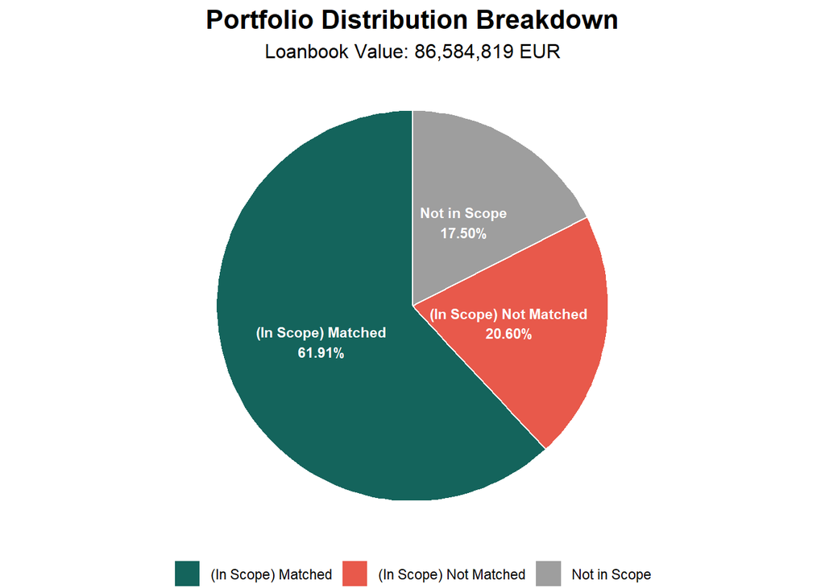

```r
#Calculation
loanbook_sector_summary <- ap_loanbook %>%
 group_by(sector_matched) %>%
  summarise(
   total_outstanding = sum(loan_size_outstanding, na.rm = TRUE)
  )
matches_sector_summary <- matches %>%
  group_by(sector) %>%
   summarise(
     matches_outstanding = sum(loan_size_outstanding, na.rm = TRUE)
   )
sector_summary <- loanbook_sector_summary %>%
  left_join(matches_sector_summary, by = c("sector_matched" = "sector")) %>%
  mutate(
    matches_outstanding = ifelse(is.na(matches_outstanding), 0, matches_outstanding),
    match_percentage = (matches_outstanding / total_outstanding) * 100
  )

#Pie Chart
outstanding_total <- sum(sector_summary$total_outstanding)
outstanding_matched <- sum(sector_summary$matches_outstanding)
outstanding_notinscope <- loanbook_sector_summary %>%
  filter(sector_matched == "not in scope") %>%
  pull(total_outstanding)

df_sector_pie <- data.frame(
  status = c("(In Scope) Matched", "(In Scope) Not Matched", "Not in Scope"),
  amount = c(
    outstanding_matched,
    (outstanding_total - outstanding_notinscope - outstanding_matched),
    outstanding_notinscope
  )
) %>%
  mutate(
    percent = amount / sum(amount),
    label = paste0(status, "\n", percent(percent, accuracy = 0.01))
  )

ggplot(df_sector_pie, aes(x = "", y = amount, fill = status)) +
  geom_bar(stat = "identity", width = 1, color = "white") +
  coord_polar("y", start = 0) +
  geom_text(aes(label = label),
            position = position_stack(vjust = 0.5),
            color = "white",
            fontface = "bold",
            size = 3) +
  scale_fill_manual(values = c(
    "(In Scope) Matched" = "#14645c",
    "(In Scope) Not Matched" = "#e8594b",
    "Not in Scope" = "#9E9E9E"
  )) +
  labs(
    title = "Portfolio Distribution Breakdown",
    subtitle = paste0("Loanbook Value: ", comma(outstanding_total), " EUR"),
    fill = NULL
  ) +
  theme_void() +
  theme(
    legend.position = "bottom",
    plot.title = element_text(hjust = 0.5, face = "bold", size = 16),
    plot.subtitle = element_text(hjust = 0.5, size = 12)
  )
```

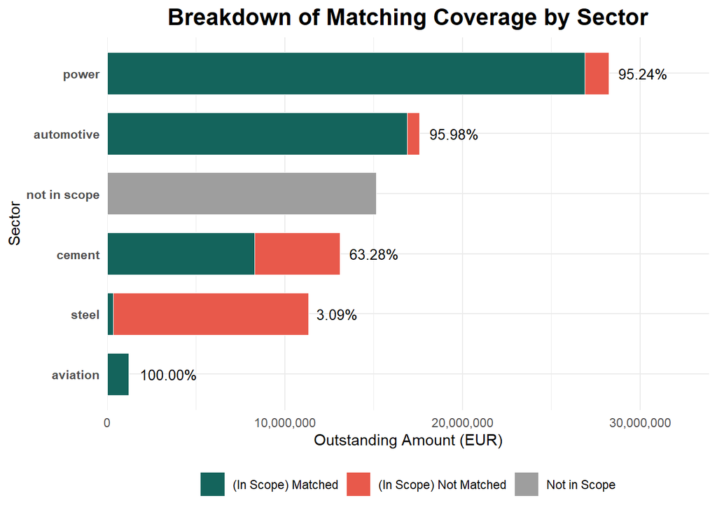

```r
#Bar Chart
df_sector_bar <- sector_summary %>%
  mutate(not_matched_outstanding = total_outstanding - matches_outstanding) %>%
  pivot_longer(
    cols = c(matches_outstanding, not_matched_outstanding),
    names_to = "type",
    values_to = "amount"
  ) %>%
  mutate(
    status = case_when(
      sector_matched == "not in scope" ~ "Not in Scope",
      type == "matches_outstanding" ~ "(In Scope) Matched",
      TRUE ~ "(In Scope) Not Matched"
    ),
  status = factor(status, levels = c("(In Scope) Matched", "(In Scope) Not Matched", "Not in Scope"))
  )

ggplot(df_sector_bar, aes(x = reorder(sector_matched, amount, sum), y = amount, fill = status)) +
  geom_col(width = 0.7, color = "white", linewidth = 0.1,position=position_stack(reverse=TRUE)) +
  geom_text(data = sector_summary %>% filter(sector_matched != "not in scope"),
            aes(x = sector_matched, y = total_outstanding,
                label = percent(match_percentage/100, accuracy = 0.01)),
            inherit.aes = FALSE,
            hjust = -0.2,
            size = 3.5) +
  coord_flip() +
  scale_y_continuous(labels = label_comma(), expand = expansion(mult = c(0, 0.2))) +
  scale_fill_manual(values = c(
    "(In Scope) Matched" = "#14645c",
    "(In Scope) Not Matched" = "#e8594b",
    "Not in Scope" = "#9E9E9E"
  )) +
  labs(
    title = "Breakdown of Matching Coverage by Sector",
    x = "Sector",
    y = "Outstanding Amount (EUR)",
    fill = NULL
  ) +
  theme_minimal() +
  theme(
    legend.position = "bottom",
    axis.text.y = element_text(face = "bold"),
    plot.title = element_text(hjust = 0.5, face = "bold", size = 16)
  )
```

### **3.4. Calculate PACTA alignment metrics**

#### **3.4.1. Calculate alignment for Power & Automotive Sectors by Market Share Approach**

##### **3.4.1.1. Sector-level: Technology Mix**

- Function: `target_market_share`

```r
market_share_targets_portfolio <-
  target_market_share(
    data = matches %>%
      select(-c("sector_matched", "borderline_matched")),
    abcd = ap_abcd,
    scenario = scenario,
    region_isos = region
  )
unique(market_share_targets_portfolio$sector)
```

```
## [1] "automotive" "power"
```

```r
head(market_share_targets_portfolio)
```

```
## # A tibble: 6 × 10
##   sector     technology  year region scenario_source metric     production
##   <chr>      <chr>      <int> <chr>  <chr>           <chr>           <dbl>
## 1 automotive electric    2020 global demo_2020       projected     145649.
## 2 automotive electric    2020 global demo_2020       target_cps    145649.
## 3 automotive electric    2020 global demo_2020       target_sds    145649.
## 4 automotive electric    2020 global demo_2020       target_sps    145649.
## 5 automotive electric    2021 global demo_2020       projected     147480.
## 6 automotive electric    2021 global demo_2020       target_cps    148314.
## # ℹ 3 more variables: technology_share <dbl>, scope <chr>,
## #   percentage_of_initial_production_by_scope <dbl>
```

- **Power Sector**  
  Note: If you take a look at the graph, you can see portfolio in 2025 is empty. This is because the data projected for 2025 for capacity did not add up to 100%.

```
## The `technology_share` values are plotted for extreme years.
## Do you want to plot different years? E.g. filter . with:`subset(., year %in% c(2020, 2030))`.
```

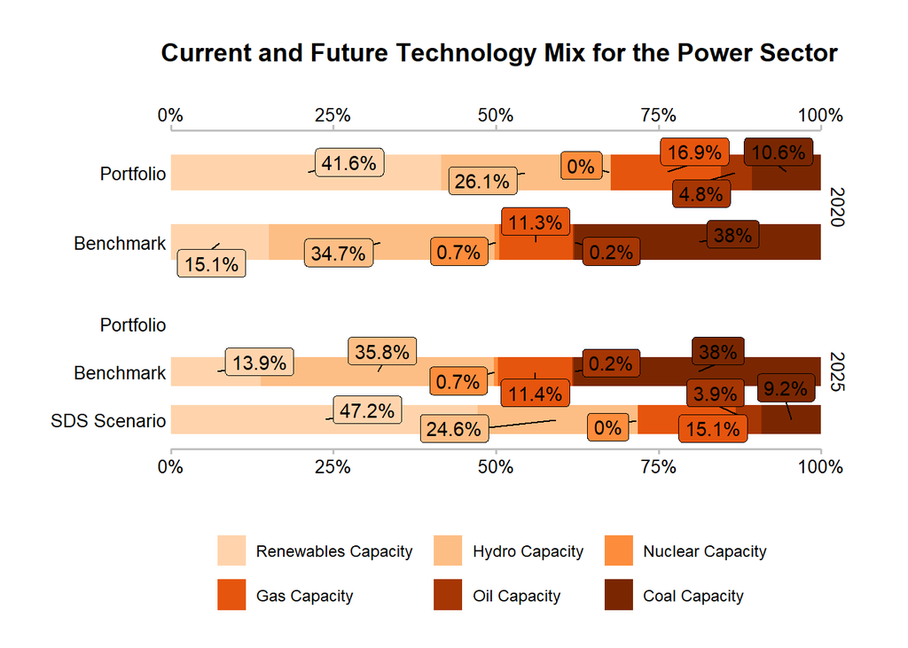

```r
data_portfolio <- filter(
  market_share_targets_portfolio,
  scenario_source == "demo_2020",
  sector == "power",
  region == "global",
  metric %in% c("projected", "corporate_economy", "target_sds")
)

qplot_techmix(data_portfolio) +
  ggrepel::geom_label_repel(
    aes(label = paste0(round(technology_share, 3) * 100, "%")),
    min.segment.length = 0,
    position = position_stack(vjust = 0.5),
    show.legend = FALSE
  ) +
  theme(text=element_text(family="sans"))
```

- **Automotive Sector**

```
## The `technology_share` values are plotted for extreme years.
## Do you want to plot different years? E.g. filter . with:`subset(., year %in% c(2020, 2030))`.
```

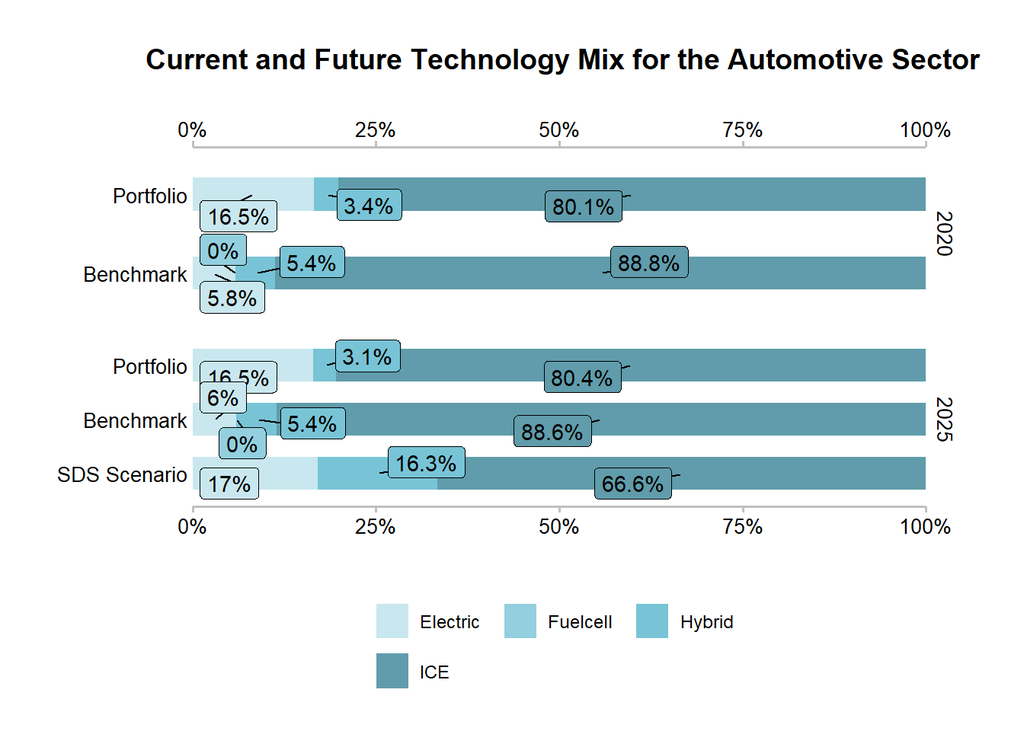

```r
data_portfolio <- filter(
  market_share_targets_portfolio,
  scenario_source == "demo_2020",
  sector == "automotive",
  region == "global",
  metric %in% c("projected", "corporate_economy", "target_sds")
)

qplot_techmix(data_portfolio) +
  ggrepel::geom_label_repel(
    aes(label = paste0(round(technology_share, 3) * 100, "%")),
    min.segment.length = 0,
    position = position_stack(vjust = 0.5),
    show.legend = FALSE
  ) +
  theme(text=element_text(family="sans"))
```

##### **3.4.1.2. Technology-level Production Volume Trajectory**

- **Power Sector**

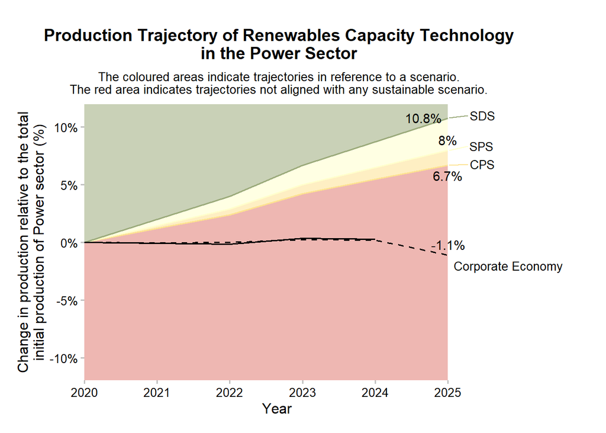

```r
#Renewables
data_portfolio <- filter(
  market_share_targets_portfolio,
  sector == "power",
  technology == "renewablescap",
  region == "global",
  scenario_source == "demo_2020"
)

data_renewablescap <- data_portfolio %>%
  dplyr::filter(year == min(.data$year) + 5) %>%
  dplyr::rename(value = "percentage_of_initial_production_by_scope")

qplot_trajectory(data_portfolio) +
  ggrepel::geom_text_repel(
    aes(label = paste0(round(value, 3) * 100, "%")),
    data = data_renewablescap
  ) +
  theme(text=element_text(family="sans"))
```

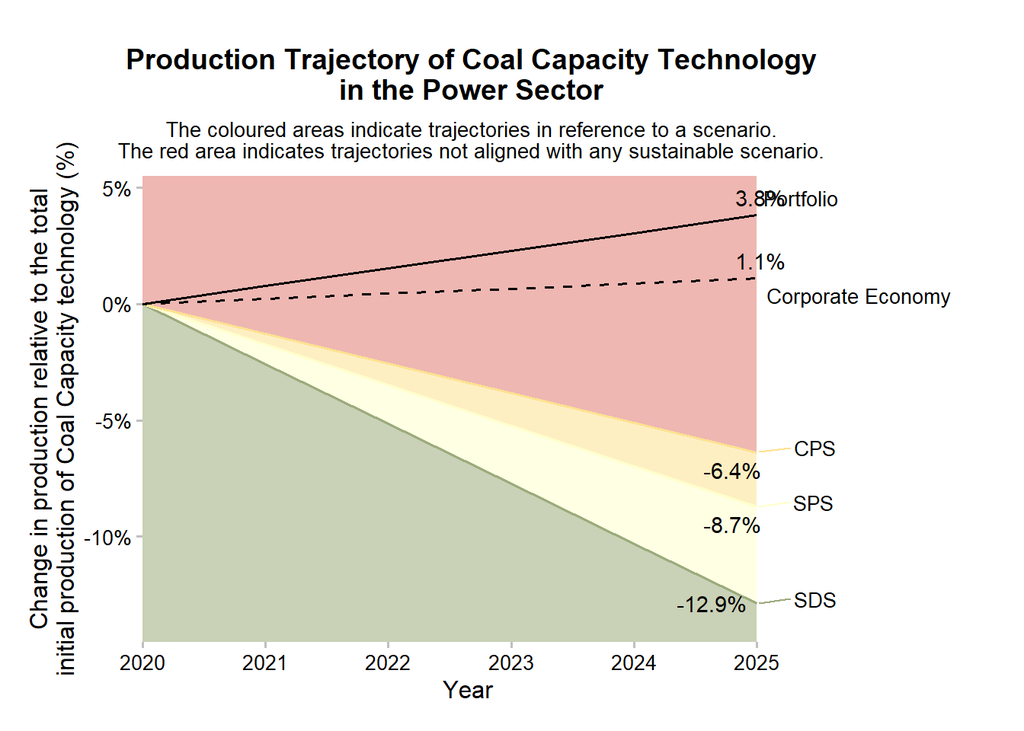

```r
#Coal
data_portfolio <- filter(
  market_share_targets_portfolio,
  sector == "power",
  technology == "coalcap",
  region == "global",
  scenario_source == "demo_2020"
)

data_coalcap <- data_portfolio %>%
  dplyr::filter(year == min(.data$year) + 5) %>%
  dplyr::rename(value = "percentage_of_initial_production_by_scope")

qplot_trajectory(data_portfolio) +
  ggrepel::geom_text_repel(
    aes(label = paste0(round(value, 3) * 100, "%")),
    data = data_coalcap
  )+
  theme(text=element_text(family="sans"))
```

- **Automotive Sector**

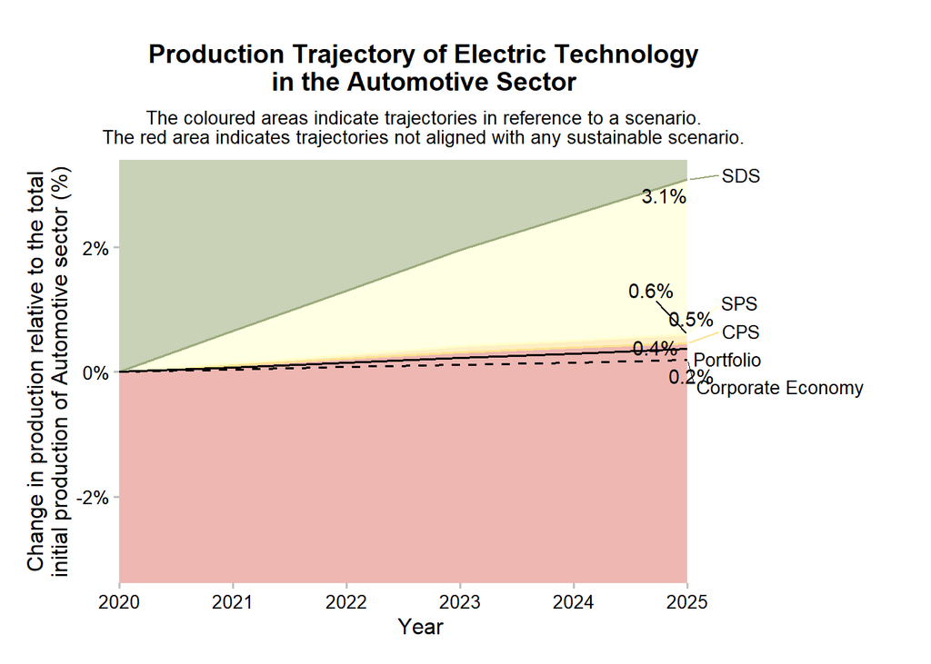

```r
#Electric
data_portfolio <- filter(
  market_share_targets_portfolio,
  sector == "automotive",
  technology == "electric",
  region == "global",
  scenario_source == "demo_2020"
)

data_electric_auto <- data_portfolio %>%
  dplyr::filter(year == min(.data$year) + 5) %>%
  dplyr::rename(value = "percentage_of_initial_production_by_scope")

qplot_trajectory(data_portfolio) +
  ggrepel::geom_text_repel(
    aes(label = paste0(round(value, 3) * 100, "%")),
    data = data_electric_auto
  )+
  theme(text=element_text(family="sans"))
```

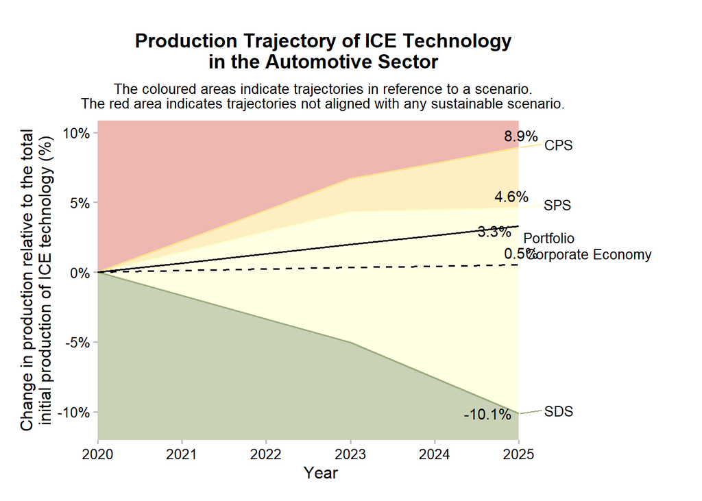

```r
#Combustion engine
data_portfolio <- filter(
  market_share_targets_portfolio,
  sector == "automotive",
  technology == "ice",
  region == "global",
  scenario_source == "demo_2020"
)

data_ice_auto <- data_portfolio %>%
  dplyr::filter(year == min(.data$year) + 5) %>%
  dplyr::rename(value = "percentage_of_initial_production_by_scope")

qplot_trajectory(data_portfolio) +
  ggrepel::geom_text_repel(
    aes(label = paste0(round(value, 3) * 100, "%")),
    data = data_ice_auto
  )+
  theme(text=element_text(family="sans"))
```

#### **3.4.2 Calculate alignment for Cement and Steel Sectors by Sectoral Decarbonization Approach**

- Funtion: `target_sda`

```r
sda_targets_portfolio <-
  target_sda(
    data = matches,
    abcd = ap_abcd,
    co2_intensity_scenario = co2,
    region_isos = region)
unique(sda_targets_portfolio$sector)
```

```
## [1] "cement" "steel"
```

```r
head(sda_targets_portfolio)
```

```
## # A tibble: 6 × 6
##   sector  year region             scenario_source emission_factor_metric
##   <chr>  <dbl> <chr>              <chr>           <chr>
## 1 cement  2020 advanced economies demo_2020       projected
## 2 cement  2020 developing asia    demo_2020       projected
## 3 cement  2020 global             demo_2020       projected
## 4 cement  2021 advanced economies demo_2020       projected
## 5 cement  2021 developing asia    demo_2020       projected
## 6 cement  2021 global             demo_2020       projected
## # ℹ 1 more variable: emission_factor_value <dbl>
```

- **Cement**

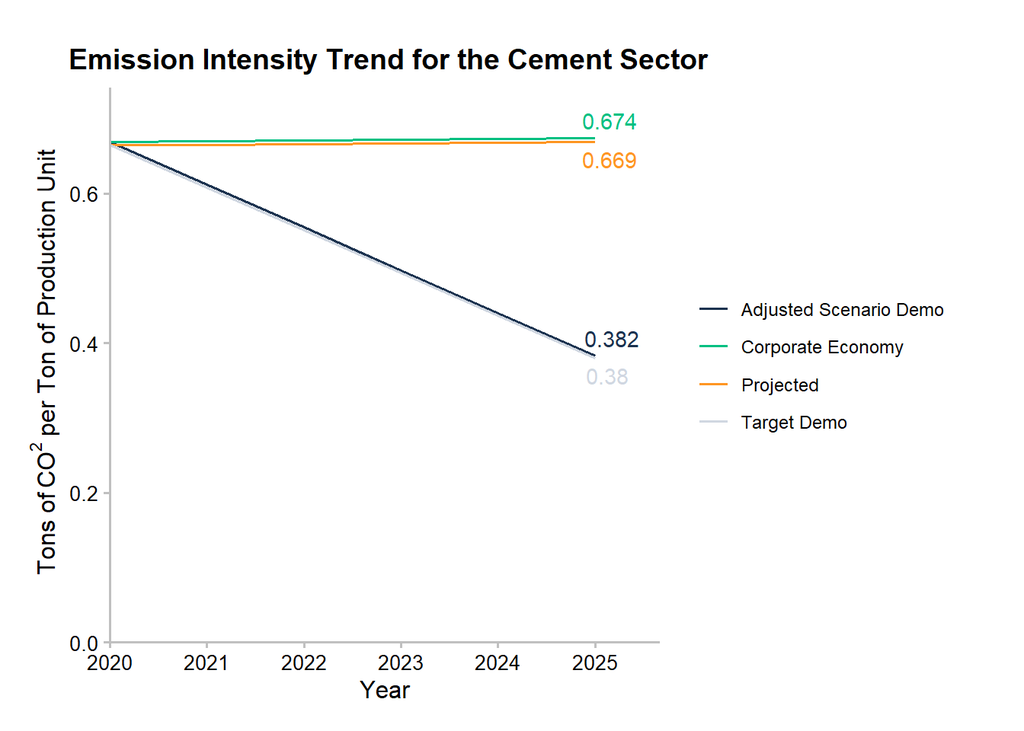

```r
data_portfolio <- filter(
  sda_targets_portfolio,
  sector == "cement",
  region == "global"
)

data_cement <- data_portfolio %>%
  dplyr::filter(year == min(.data$year) + 5) %>%
  dplyr::mutate(
    year = as.Date(strptime(as.character(year), "%Y")),
    label = pacta.loanbook::to_title(emission_factor_metric)
  )

qplot_emission_intensity(data_portfolio) +
  ggrepel::geom_text_repel(
    aes(label = round(emission_factor_value, 3)),
    data = data_cement,
    show.legend = FALSE
  )+
  theme(text=element_text(family="sans"))
```

- **Steel**

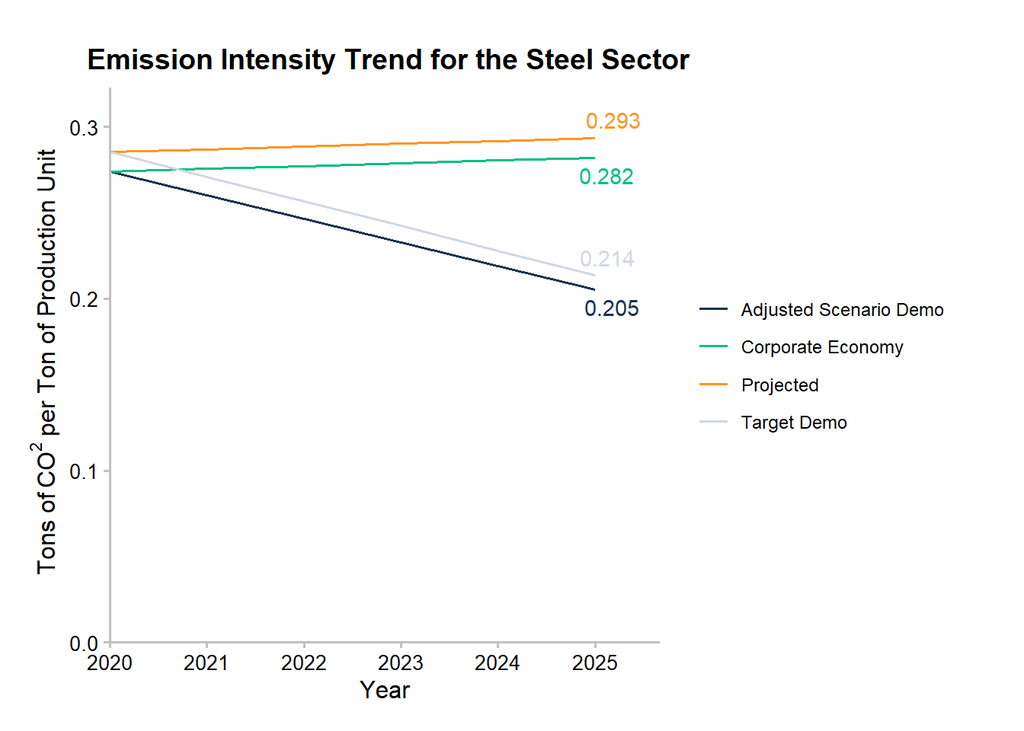

```r
data_portfolio <- filter(
  sda_targets_portfolio,
  sector == "steel",
  region == "global"
)

data_steel <- data_portfolio %>%
  dplyr::filter(year == min(.data$year) + 5) %>%
  dplyr::mutate(
    year = as.Date(strptime(as.character(year), "%Y")),
    label = pacta.loanbook::to_title(emission_factor_metric)
  )

qplot_emission_intensity(data_portfolio) +
  ggrepel::geom_text_repel(
    aes(label = round(emission_factor_value, 3)),
    data = data_steel,
    show.legend = FALSE
  )+
  theme(text=element_text(family="sans"))
```